# Residual Analysis and Different Models for Electricity Demand

Sulalitha Bowala

```r
rm(list=ls(all=TRUE)) # Remove objects from environment
set.seed(12)
```

## Ontario Data

```r
### Call packages
require("tseries") # load the tseries library
require("zoo")
require("moments")
require("car")
require("MASS")
require("stats")
require("VGAM")
require("fGarch")
require("quantmod") # To download data alternatively
```

```r
require("PerformanceAnalytics") # To draw Timeseries graphs
require("scales")
require("PEIP")
require("dplyr")
require("lubridate")
require("tidyverse")
require("gridExtra")
require("gdata")
require("xtable")
require("vioplot")
require("fpp3")
require("readr")
require("tis")
require("tibble")
require("tsibble")
require("stringr")
require("magrittr")
require("fable")
require("Metrics") # rmse()
require("forecast")
## Import data

Ontario_demand_hourly <- read.csv("Data_2018_2019.csv")
```

```r
### Manupulate hourly data to obtain daily data
### + create a new categorical variable (day-type)

## Ontario data

Ontario_demand_hourly$Time <- as.POSIXct(Ontario_demand_hourly$Time, "%Y-%m-%d %H:%M:%S")
```

```r
Ontario_demand_hourly$Demand <- Ontario_demand_hourly$Demand
Ontario_demand_hourly$Temperature <- Ontario_demand_hourly$Temperature
Ontario_demand_hourly$Precipitation <- Ontario_demand_hourly$Precipitation
Ontario_demand_hourly$CloudCover <- Ontario_demand_hourly$CloudCover
Ontario_demand_hourly$IrradianceSurface <- Ontario_demand_hourly$IrradianceSurface
Ontario_demand_hourly$IrradianceToa <- Ontario_demand_hourly$IrradianceToa
Ontario_demand_hourly$Snowfall <- Ontario_demand_hourly$Snowfall
Ontario_demand_hourly$SnowMass <- Ontario_demand_hourly$SnowMass
Ontario_demand_hourly$Location <- Ontario_demand_hourly$Location
Ontario_demand_hourly <- as_tsibble(Ontario_demand_hourly,index = 'Time',key = 'Location')

Ontario_demand_hourly <- Ontario_demand_hourly %>%
  mutate(
    Date = date( Time)
  )
Ontario_demand_hourly <- Ontario_demand_hourly %>%
  mutate(
    Holiday = isHoliday(Ontario_demand_hourly$Date)
  )
Ontario_demand_hourly <- Ontario_demand_hourly %>%
 mutate(Day_Type = case_when(
    Holiday ~ "Holiday",
    wday(Date) %in% 2:6 ~ "Weekday",
    TRUE ~ "Weekend"
  ))
#
head(Ontario_demand_hourly)
```

```
## # A tsibble: 6 x 14 [1h] <%Y-%m-%d %H:%M:%S>
## # Key:       Location [6]
```

```
##   Time                Precipitation Temperature IrradianceSurface IrradianceToa
##   <dttm>                      <dbl>       <dbl>             <dbl>         <dbl>
## 1 2018-01-01 00:00:00        0.0099       -16.7                 0             0
## 2 2018-01-01 01:00:00        0.0112       -17.0                 0             0
## 3 2018-01-01 02:00:00        0.0113       -17.2                 0             0
## 4 2018-01-01 03:00:00        0.0125       -17.5                 0             0
## 5 2018-01-01 04:00:00        0.0156       -17.7                 0             0
## 6 2018-01-01 05:00:00        0.0191       -17.7                 0             0
## # ℹ 9 more variables: Snowfall <dbl>, SnowMass <dbl>, CloudCover <dbl>,
## #   AirDensity <dbl>, Demand <int>, Location <int>, Date <date>, Holiday <lgl>,
## #   Day_Type <chr>
```

```r
tail(Ontario_demand_hourly)
```

```
## # A tsibble: 6 x 14 [1h] <%Y-%m-%d %H:%M:%S>
## # Key:       Location [6]
```

```
##   Time                Precipitation Temperature IrradianceSurface IrradianceToa
##   <dttm>                      <dbl>       <dbl>             <dbl>         <dbl>
## 1 2019-12-31 18:00:00        0.229       -0.519           99.3         497.
## 2 2019-12-31 19:00:00        0.172       -0.6             74.7         394.
## 3 2019-12-31 20:00:00        0.143       -0.73            45.3         237.
## 4 2019-12-31 21:00:00        0.123       -0.999            9.47         52.2
## 5 2019-12-31 22:00:00        0.0986      -1.26             0.0079        0.0352
## 6 2019-12-31 23:00:00        0.0625      -1.48             0             0
## # ℹ 9 more variables: Snowfall <dbl>, SnowMass <dbl>, CloudCover <dbl>,
## #   AirDensity <dbl>, Demand <int>, Location <int>, Date <date>, Holiday <lgl>,
## #   Day_Type <chr>
```

```r
## Rename columns

Ontario_demand_hourly<-Ontario_demand_hourly[,c("Time","Precipitation","Temperature","IrradianceSurface","IrradianceToa","Snowfall","SnowMass","CloudCover","AirDensity","Demand","Location","Date","Holiday","Day_Type")]
```

```r
## Daily data

# Ontario data
Ontario.Daily <- Ontario_demand_hourly %>%

  index_by(Date = date(Time)) %>%
  summarise(
    Demand = mean(Demand),
    Temperature = mean(Temperature),
    Holiday = any(Holiday),
    Precipitation = mean(Precipitation),
    IrradianceSurface = mean(IrradianceSurface),
    IrradianceToa = mean(IrradianceToa),
    Snowfall = mean(Snowfall),
    SnowMass = mean(SnowMass),
    CloudCover = mean(CloudCover),
    AirDensity = mean(AirDensity),
  ) %>%
  mutate(Day_Type = case_when(
    Holiday ~ "Holiday",
    wday(Date) %in% 2:6 ~ "Weekday",
    TRUE ~ "Weekend"
  ))
Ontario.Daily <- Ontario.Daily %>%
  mutate(Temperature2 = Temperature^2,
         HolidayNew = if_else(Holiday == "TRUE", 1, 0),
         Day_TypeNew = if_else(Day_Type == "Weekday", 1, 0))

head(Ontario.Daily)
```

```
## # A tsibble: 6 x 15 [1D]
##   Date       Demand Temperature Holiday Precipitation IrradianceSurface
##   <date>      <dbl>       <dbl> <lgl>           <dbl>             <dbl>
## 1 2018-01-01 16931.       -14.9 TRUE           0.0216              52.0
## 2 2018-01-02 17953.       -11.4 FALSE          0.0244              41.9
## 3 2018-01-03 18123.       -10.3 FALSE          0.0231              48.7
## 4 2018-01-04 18050.       -11.2 FALSE          0.0263              56.7
## 5 2018-01-05 18961.       -17.6 FALSE          0.0532              42.2
## 6 2018-01-06 18514.       -18.5 FALSE          0.0181              47.7
## # ℹ 9 more variables: IrradianceToa <dbl>, Snowfall <dbl>, SnowMass <dbl>,
## #   CloudCover <dbl>, AirDensity <dbl>, Day_Type <chr>, Temperature2 <dbl>,
## #   HolidayNew <dbl>, Day_TypeNew <dbl>
```

```r
tail(Ontario.Daily)
```

```
## # A tsibble: 6 x 15 [1D]
##   Date       Demand Temperature Holiday Precipitation IrradianceSurface
##   <date>      <dbl>       <dbl> <lgl>           <dbl>             <dbl>
## 1 2019-12-26 14145.      0.462  FALSE         0.0152               22.7
## 2 2019-12-27 14385.      4.19   FALSE         0.0257               65.4
## 3 2019-12-28 14316.      0.0134 FALSE         0.00906              80.0
## 4 2019-12-29 14671.     -0.148  FALSE         0.156                16.9
## 5 2019-12-30 15018.      1.87   FALSE         0.307                59.6
## 6 2019-12-31 14699      -0.362  FALSE         0.183                24.1
## # ℹ 9 more variables: IrradianceToa <dbl>, Snowfall <dbl>, SnowMass <dbl>,
## #   CloudCover <dbl>, AirDensity <dbl>, Day_Type <chr>, Temperature2 <dbl>,
## #   HolidayNew <dbl>, Day_TypeNew <dbl>
```

whether data: https://www.renewables.ninja/

We believe Temperature is affected by other covariates (Precipitation, IrradianceSurface, IrradianceToa, Snowfall, SnowMass, CloudCover, AirDensity) available in the data.

Description of covariates:

Air temperature (°C): Air temperature at 2 meters above ground. T2M variable in MERRA-2, converted from K.

Precipitation (mm / hour): Total bias-corrected precipitation, over land only. PRECTOTLAND variable in MERRA-2, converted from kg m⁻² s⁻¹

Snowfall (mm / hour): Total bias-corrected precipitation in the form of snow, over land only. PRECSNOLAND variable in MERRA-2, converted from kg m⁻² s⁻¹

Snow mass (kg / m²): Amount of snow per land area. SNOMAS variable in MERRA-2, in native units.

Air density (kg / m³): Air density at ground level. RHOA variable in MERRA-2, in native units.

Ground-level solar irradiance (W / m²): Surface-level incident shortwave radiation flux, considering cloud cover and aerosols. SWGDN variable in MERRA-2, in native units. Note, MERRA-2 uses the mean annual climate for aerosols, rather than time-varying quantity.

Top of atmosphere solar irradiance (W / m²): Top of atmosphere incident shortwave radiation flux, before cloud cover and aerosol influences. SWTDN variable in MERRA-2, in native units.

Cloud cover fraction: Fraction of cloud cover, averaged over grid cell and summed over all height above ground. CLDTOT variable in MERRA-2, in native units (a [0, 1] scale).

Check for multicollinearity among selected variables (Precipitation, IrradianceSurface, IrradianceToa, Snowfall, SnowMass, CloudCover, AirDensity).

```r
## VIF (Variance Inflation Factor)

library(car)

model.VIF <- lm(Temperature ~ Precipitation + IrradianceSurface + IrradianceToa + Snowfall + SnowMass + CloudCover + AirDensity, data = Ontario.Daily)

summary(model.VIF)
```

```
##
## Call:
## lm(formula = Temperature ~ Precipitation + IrradianceSurface +
##     IrradianceToa + Snowfall + SnowMass + CloudCover + AirDensity,
##     data = Ontario.Daily)
##
## Residuals:
##     Min      1Q  Median      3Q     Max
## -4.9807 -1.1396 -0.0165  1.1656  4.1187
##
## Coefficients:
##                     Estimate Std. Error t value Pr(>|t|)
## (Intercept)        2.378e+02  2.756e+00  86.309  < 2e-16 ***
## Precipitation     -3.067e+00  7.219e-01  -4.248 2.43e-05 ***
## IrradianceSurface  5.755e-03  2.105e-03   2.734 0.006406 **
## IrradianceToa      1.175e-03  1.410e-03   0.834 0.404721
## Snowfall          -3.654e+00  1.695e+00  -2.156 0.031444 *
## SnowMass          -5.288e-02  1.555e-02  -3.402 0.000707 ***
## CloudCover        -7.400e-01  4.284e-01  -1.727 0.084540 .
## AirDensity        -1.878e+02  2.137e+00 -87.897  < 2e-16 ***
## ---
## Signif. codes:  0 '***' 0.001 '**' 0.01 '*' 0.05 '.' 0.1 ' ' 1
##
## Residual standard error: 1.647 on 722 degrees of freedom
## Multiple R-squared:  0.978,  Adjusted R-squared:  0.9778
## F-statistic:  4588 on 7 and 722 DF,  p-value: < 2.2e-16
```

```r
# Calculate VIF for selected variables
vif_values <- vif(model.VIF)

# Print VIF values
print(vif_values)
```

```
##     Precipitation IrradianceSurface     IrradianceToa          Snowfall
##          1.887588         10.637492          8.480953          1.732499
##          SnowMass        CloudCover        AirDensity
##          2.325717          2.896599          3.594158
```

The Variance Inflation Factor (VIF) is a measure that quantifies how much the variance of an estimated regression coefficient increases if your predictors are correlated. High VIF values (typically > 10) may indicate problematic levels of multicollinearity.

Only for IrradianceSurface we observe a VIF value greater than 10 and VIF of IrradianceToa is close to 10.

```r
## Correlation Matrix

Temp.Ontario.Daily <- Ontario.Daily

colnames(Temp.Ontario.Daily) <- c("Date","Demand","Temperature","Holiday",
                                  "Precipitation","Irradiance (surface)",
                                  "Irradiance (atmosphere)","Snowfall",
                                  "Snow Mass","Cloud Cover","Air Density",
                                  "Day_Type","Temperature2",
                                  "HolidayNew","Day_TypeNew")

# Create a correlation matrix for selected variables
cor_matrix <- cor(Temp.Ontario.Daily[, c("Precipitation", "Irradiance (surface)", "Irradiance (atmosphere)", "Snowfall",  "Snow Mass",  "Cloud Cover", "Air Density")])

# Print the correlation matrix
print(cor_matrix)
```

```
##                         Precipitation Irradiance (surface)
## Precipitation              1.00000000           -0.1867873
## Irradiance (surface)      -0.18678730            1.0000000
## Irradiance (atmosphere)    0.06549682            0.8585024
## Snowfall                   0.43440558           -0.3725886
## Snow Mass                 -0.07238484           -0.5092769
## Cloud Cover                0.39610517           -0.6143980
## Air Density               -0.19473430           -0.6453389
##                         Irradiance (atmosphere)   Snowfall   Snow Mass
## Precipitation                        0.06549682  0.4344056 -0.07238484
## Irradiance (surface)                 0.85850244 -0.3725886 -0.50927687
## Irradiance (atmosphere)              1.00000000 -0.3041690 -0.57578498
## Snowfall                            -0.30416898  1.0000000  0.42130753
## Snow Mass                           -0.57578498  0.4213075  1.00000000
## Cloud Cover                         -0.26407432  0.3135428  0.24889562
## Air Density                         -0.74765953  0.3490269  0.72780921
##                         Cloud Cover Air Density
## Precipitation             0.3961052  -0.1947343
## Irradiance (surface)     -0.6143980  -0.6453389
## Irradiance (atmosphere)  -0.2640743  -0.7476595
## Snowfall                  0.3135428   0.3490269
## Snow Mass                 0.2488956   0.7278092
## Cloud Cover               1.0000000   0.2308716
## Air Density               0.2308716   1.0000000
```

High correlation coefficients (close to 1 or -1) may suggest multicollinearity.

Corr(IrradianceToa, IrradianceSurface) = 0.8585024 Corr(IrradianceSurface, CloudCover) = -0.6143980 Corr(IrradianceSurface, AirDensity) = -0.6453389 Corr(IrradianceToa, AirDensity) = -0.7476595

We can visualize the correlation matrix using tools like corrplot for better insight:

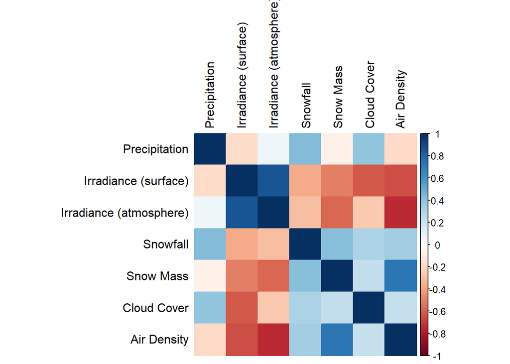

```r
library(corrplot)
# Plot the correlation matrix
corrplot(cor_matrix, method = "color", tl.col="black")
```

Thus, we may omit “IrradianceSurface” and “IrradianceToa” from future models for Temperature to avoid multicollinearity.

### Choose best model to obtain fuzzily forecast of Temperature

Note that some models consider only lagged values of temperature. However, in some models we incorporate other covariates as well.

```r
### Mean Model
MeanModel.Temp <- Ontario.Daily %>%
  model(MEAN(Temperature))

fore.Mean.Temp <- MeanModel.Temp %>% forecast(Ontario.Daily)

Mean.Test.Accuracy <- fabletools::accuracy(fore.Mean.Temp, Ontario.Daily)

xtable(Mean.Test.Accuracy)
```

```
## % latex table generated in R 4.4.0 by xtable 1.8-4 package
## % Fri Jan  3 15:14:38 2025
## \begin{table}[ht]
## \centering
## \begin{tabular}{rllrrrrrrrr}
##   \hline
##  & .model & .type & ME & RMSE & MAE & MPE & MAPE & MASE & RMSSE & ACF1 \\
##   \hline
## 1 & MEAN(Temperature) & Test & 0.00 & 11.05 & 9.71 & 193.47 & 581.53 &  &  & 0.96 \\
##    \hline
## \end{tabular}
## \end{table}
```

```r
## Naive Model
NaiveModel.Temp <- Ontario.Daily %>%
  model(NAIVE(Temperature))

fore.Naive.Temp <- NaiveModel.Temp %>% forecast(Ontario.Daily)

Naive.Test.Accuracy <- fabletools::accuracy(fore.Naive.Temp, Ontario.Daily)

xtable(Naive.Test.Accuracy)
```

```
## % latex table generated in R 4.4.0 by xtable 1.8-4 package
## % Fri Jan  3 15:14:38 2025
## \begin{table}[ht]
## \centering
## \begin{tabular}{rllrrrrrrrr}
##   \hline
##  & .model & .type & ME & RMSE & MAE & MPE & MAPE & MASE & RMSSE & ACF1 \\
##   \hline
## 1 & NAIVE(Temperature) & Test & 7.90 & 13.58 & 10.90 & 95.51 & 113.97 &  &  & 0.96 \\
##    \hline
## \end{tabular}
## \end{table}
```

```r
### Seasonal Naive Model
SNaiveModel.Temp <- Ontario.Daily %>%
  model(SNAIVE(Temperature))

fore.SNaive.Temp <- SNaiveModel.Temp %>% forecast(Ontario.Daily)

SNaive.Test.Accuracy <- fabletools::accuracy(fore.SNaive.Temp, Ontario.Daily)

xtable(SNaive.Test.Accuracy)
```

```
## % latex table generated in R 4.4.0 by xtable 1.8-4 package
## % Fri Jan  3 15:14:39 2025
## \begin{table}[ht]
## \centering
## \begin{tabular}{rllrrrrrrrr}
##   \hline
##  & .model & .type & ME & RMSE & MAE & MPE & MAPE & MASE & RMSSE & ACF1 \\
##   \hline
## 1 & SNAIVE(Temperature) & Test & 6.78 & 13.06 & 10.60 & 65.31 & 157.73 &  &  & 0.94 \\
##    \hline
## \end{tabular}
## \end{table}
```

```r
### Drift Model
DriftModel.Temp <- Ontario.Daily %>%
  model(RW(Temperature~drift()))

fore.Drift.Temp <- DriftModel.Temp %>% forecast(Ontario.Daily)

Drif.Test.Accuracy <- fabletools::accuracy(fore.Drift.Temp, Ontario.Daily)

xtable(Drif.Test.Accuracy)
```

```
## % latex table generated in R 4.4.0 by xtable 1.8-4 package
## % Fri Jan  3 15:14:39 2025
## \begin{table}[ht]
## \centering
## \begin{tabular}{rllrrrrrrrr}
##   \hline
##  & .model & .type & ME & RMSE & MAE & MPE & MAPE & MASE & RMSSE & ACF1 \\
##   \hline
## 1 & RW(Temperature \~{} drift()) & Test & 0.60 & 11.31 & 9.51 & 38.46 & 507.21 &  &  & 0.97 \\
##    \hline
## \end{tabular}
## \end{table}
```

```r
library(fable.prophet)
### Prophet Model
ProphetModel.Temp1 <- Ontario.Daily %>%
  model(prophet(Temperature))

fore.Prophet.Temp1 <- ProphetModel.Temp1 %>% forecast(Ontario.Daily)

Prophet.Test.Accuracy1 <- fabletools::accuracy(fore.Prophet.Temp1, Ontario.Daily)

xtable(Prophet.Test.Accuracy1)
```

```
## % latex table generated in R 4.4.0 by xtable 1.8-4 package
## % Fri Jan  3 15:15:10 2025
## \begin{table}[ht]
## \centering
## \begin{tabular}{rllrrrrrrrr}
##   \hline
##  & .model & .type & ME & RMSE & MAE & MPE & MAPE & MASE & RMSSE & ACF1 \\
##   \hline
## 1 & prophet(Temperature) & Test & 0.00 & 3.34 & 2.54 & -6.73 & 235.62 &  &  & 0.64 \\
##    \hline
## \end{tabular}
## \end{table}
```

```r
### Prophet Model
ProphetModel.Temp2 <- Ontario.Daily %>%
  model(prophet(Temperature ~ Precipitation + Snowfall + SnowMass + CloudCover + AirDensity))

fore.Prophet.Temp2 <- ProphetModel.Temp2 %>% forecast(Ontario.Daily)

Prophet.Test.Accuracy2 <- fabletools::accuracy(fore.Prophet.Temp2, Ontario.Daily)

xtable(Prophet.Test.Accuracy2)
```

```
## % latex table generated in R 4.4.0 by xtable 1.8-4 package
## % Fri Jan  3 15:15:21 2025
## \begin{table}[ht]
## \centering
## \begin{tabular}{rllrrrrrrrr}
##   \hline
##  & .model & .type & ME & RMSE & MAE & MPE & MAPE & MASE & RMSSE & ACF1 \\
##   \hline
## 1 & prophet(Temperature \~{} Precipitation + Snowfall + SnowMass + CloudCover +
##     AirDensity) & Test & 0.00 & 1.21 & 0.96 & -10.24 & 92.20 &  &  & 0.66 \\
##    \hline
## \end{tabular}
## \end{table}
```

```r
### ARIMA Model
ARIMAModel.Temp1 <- Ontario.Daily %>%
  model(ARIMA(Temperature))

## Note: Here manipulate date variable to obtain accuracy.
## Forecasts from an ARIMA model must start one step beyond the end of the trained data.
test <- Ontario.Daily %>%
  mutate(Date = seq(as.Date("2020-01-01"), as.Date("2021-12-30"), by = "day"))

fore.ARIMA.Temp1 <- ARIMAModel.Temp1 %>% forecast(test)

ARIMA.Test.Accuracy1 <- fabletools::accuracy(fore.ARIMA.Temp1, test)

xtable(ARIMA.Test.Accuracy1)
```

```
## % latex table generated in R 4.4.0 by xtable 1.8-4 package
## % Fri Jan  3 15:15:23 2025
## \begin{table}[ht]
## \centering
## \begin{tabular}{rllrrrrrrrr}
##   \hline
##  & .model & .type & ME & RMSE & MAE & MPE & MAPE & MASE & RMSSE & ACF1 \\
##   \hline
## 1 & ARIMA(Temperature) & Test & 7.91 & 13.59 & 10.91 & 95.33 & 114.70 &  &  & 0.96 \\
##    \hline
## \end{tabular}
## \end{table}
```

```r
### ARIMA Model
ARIMAModel.Temp2 <- Ontario.Daily %>%
  model(ARIMA(Temperature ~ Precipitation + Snowfall + SnowMass + CloudCover + AirDensity))

## Note: Here manipulate date variable to obtain accuracy.
## Forecasts from an ARIMA model must start one step beyond the end of the trained data.
test <- Ontario.Daily %>%
  mutate(Date = seq(as.Date("2020-01-01"), as.Date("2021-12-30"), by = "day"))

fore.ARIMA.Temp2 <- ARIMAModel.Temp2 %>% forecast(test)

ARIMA.Test.Accuracy2 <- fabletools::accuracy(fore.ARIMA.Temp2, test)

xtable(ARIMA.Test.Accuracy2)
```

```
## % latex table generated in R 4.4.0 by xtable 1.8-4 package
## % Fri Jan  3 15:15:30 2025
## \begin{table}[ht]
## \centering
## \begin{tabular}{rllrrrrrrrr}
##   \hline
##  & .model & .type & ME & RMSE & MAE & MPE & MAPE & MASE & RMSSE & ACF1 \\
##   \hline
## 1 & ARIMA(Temperature \~{} Precipitation + Snowfall + SnowMass + CloudCover +
##     AirDensity) & Test & 1.35 & 3.72 & 3.02 & 7.15 & 130.57 &  &  & 0.97 \\
##    \hline
## \end{tabular}
## \end{table}
```

```r
### nnetar Model
nnetarModel.Temp1 <- Ontario.Daily %>%
  model(NNETAR(Temperature))

fore.nnetar.Temp1 <- nnetarModel.Temp1 %>% forecast(Ontario.Daily)

nnetar.Test.Accuracy1 <- fabletools::accuracy(fore.nnetar.Temp1, Ontario.Daily)

xtable(nnetar.Test.Accuracy1)
```

```
## % latex table generated in R 4.4.0 by xtable 1.8-4 package
## % Fri Jan  3 17:31:29 2025
## \begin{table}[ht]
## \centering
## \begin{tabular}{rllrrrrrrrr}
##   \hline
##  & .model & .type & ME & RMSE & MAE & MPE & MAPE & MASE & RMSSE & ACF1 \\
##   \hline
## 1 & NNETAR(Temperature) & Test & -6.84 & 12.43 & 10.34 & 213.52 & 1017.31 &  &  & 0.96 \\
##    \hline
## \end{tabular}
## \end{table}
```

```r
### nnetar Model
nnetarModel.Temp2 <- Ontario.Daily %>%
  model(NNETAR(Temperature ~ Precipitation + Snowfall + SnowMass + CloudCover + AirDensity))

fore.nnetar.Temp2 <- nnetarModel.Temp2 %>% forecast(Ontario.Daily)

nnetar.Test.Accuracy2 <- fabletools::accuracy(fore.nnetar.Temp2, Ontario.Daily)

xtable(nnetar.Test.Accuracy2)
```

```
## % latex table generated in R 4.4.0 by xtable 1.8-4 package
## % Fri Jan  3 19:57:34 2025
## \begin{table}[ht]
## \centering
## \begin{tabular}{rllrrrrrrrr}
##   \hline
##  & .model & .type & ME & RMSE & MAE & MPE & MAPE & MASE & RMSSE & ACF1 \\
##   \hline
## 1 & NNETAR(Temperature \~{} Precipitation + Snowfall + SnowMass + CloudCover +
##     AirDensity) & Test & -0.04 & 0.58 & 0.40 & -0.76 & 21.99 &  &  & 0.56 \\
##    \hline
## \end{tabular}
## \end{table}
```

```r
### EWMA Model
EWMAModel.Temp <- Ontario.Daily %>%
  model(ETS(Temperature))

fore.EWMA.Temp <- EWMAModel.Temp %>% forecast(Ontario.Daily)

EWMA.Test.Accuracy <- fabletools::accuracy(fore.EWMA.Temp, Ontario.Daily)

xtable(EWMA.Test.Accuracy)
```

```
## % latex table generated in R 4.4.0 by xtable 1.8-4 package
## % Fri Jan  3 19:57:35 2025
## \begin{table}[ht]
## \centering
## \begin{tabular}{rllrrrrrrrr}
##   \hline
##  & .model & .type & ME & RMSE & MAE & MPE & MAPE & MASE & RMSSE & ACF1 \\
##   \hline
## 1 & ETS(Temperature) & Test & 7.83 & 13.54 & 10.87 & 96.40 & 110.42 &  &  & 0.96 \\
##    \hline
## \end{tabular}
## \end{table}
```

```r
## TSLM
TSLMModel.Temp1 <- Ontario.Daily %>%
  model(TSLM(Temperature))

fore.TSLM.Temp1 <- TSLMModel.Temp1 %>% forecast(Ontario.Daily)

TSLM.Test.Accuracy1 <- fabletools::accuracy(fore.TSLM.Temp1, Ontario.Daily)

xtable(TSLM.Test.Accuracy1)
```

```
## % latex table generated in R 4.4.0 by xtable 1.8-4 package
## % Fri Jan  3 19:57:35 2025
## \begin{table}[ht]
## \centering
## \begin{tabular}{rllrrrrrrrr}
##   \hline
##  & .model & .type & ME & RMSE & MAE & MPE & MAPE & MASE & RMSSE & ACF1 \\
##   \hline
## 1 & TSLM(Temperature) & Test & -0.00 & 11.05 & 9.71 & 193.47 & 581.53 &  &  & 0.96 \\
##    \hline
## \end{tabular}
## \end{table}
```

```r
## TSLM

TSLMModel.Temp2 <- Ontario.Daily %>%
  model(TSLM(Temperature ~ Precipitation + Snowfall + SnowMass + CloudCover + AirDensity))

fore.TSLM.Temp2 <- TSLMModel.Temp2 %>% forecast(Ontario.Daily)

TSLM.Test.Accuracy2 <- fabletools::accuracy(fore.TSLM.Temp2, Ontario.Daily)

xtable(TSLM.Test.Accuracy2)
```

```
## % latex table generated in R 4.4.0 by xtable 1.8-4 package
## % Fri Jan  3 19:57:35 2025
## \begin{table}[ht]
## \centering
## \begin{tabular}{rllrrrrrrrr}
##   \hline
##  & .model & .type & ME & RMSE & MAE & MPE & MAPE & MASE & RMSSE & ACF1 \\
##   \hline
## 1 & TSLM(Temperature \~{} Precipitation + Snowfall + SnowMass + CloudCover +
##     AirDensity) & Test & 0.00 & 1.69 & 1.37 & -18.20 & 106.10 &  &  & 0.64 \\
##    \hline
## \end{tabular}
## \end{table}
```

```r
Temp.Model.Accuracy <- rbind(Mean.Test.Accuracy, Naive.Test.Accuracy, SNaive.Test.Accuracy, Drif.Test.Accuracy, Prophet.Test.Accuracy1, Prophet.Test.Accuracy2, ARIMA.Test.Accuracy1, ARIMA.Test.Accuracy2, nnetar.Test.Accuracy1, nnetar.Test.Accuracy2, EWMA.Test.Accuracy, TSLM.Test.Accuracy1, TSLM.Test.Accuracy2)
Temp.Model.Accuracy
```

```
## # A tibble: 13 × 10
##    .model         .type        ME   RMSE    MAE     MPE   MAPE  MASE RMSSE  ACF1
##    <chr>          <chr>     <dbl>  <dbl>  <dbl>   <dbl>  <dbl> <dbl> <dbl> <dbl>
##  1 "MEAN(Tempera… Test   2.77e-16 11.0    9.71  193.     582.    NaN   NaN 0.964
##  2 "NAIVE(Temper… Test   7.90e+ 0 13.6   10.9    95.5    114.    NaN   NaN 0.964
##  3 "SNAIVE(Tempe… Test   6.78e+ 0 13.1   10.6    65.3    158.    NaN   NaN 0.940
##  4 "RW(Temperatu… Test   6.04e- 1 11.3    9.51   38.5    507.    NaN   NaN 0.966
##  5 "prophet(Temp… Test   9.40e- 4  3.34   2.54   -6.73   236.    NaN   NaN 0.637
##  6 "prophet(Temp… Test   4.14e- 4  1.21   0.964 -10.2     92.2   NaN   NaN 0.661
##  7 "ARIMA(Temper… Test   7.91e+ 0 13.6   10.9    95.3    115.    NaN   NaN 0.964
##  8 "ARIMA(Temper… Test   1.35e+ 0  3.72   3.02    7.15   131.    NaN   NaN 0.971
##  9 "NNETAR(Tempe… Test  -6.84e+ 0 12.4   10.3   214.    1017.    NaN   NaN 0.962
## 10 "NNETAR(Tempe… Test  -3.58e- 2  0.576  0.398  -0.759   22.0   NaN   NaN 0.559
## 11 "ETS(Temperat… Test   7.83e+ 0 13.5   10.9    96.4    110.    NaN   NaN 0.964
## 12 "TSLM(Tempera… Test  -3.86e-15 11.0    9.71  193.     582.    NaN   NaN 0.964
## 13 "TSLM(Tempera… Test   5.15e-14  1.69   1.37  -18.2    106.    NaN   NaN 0.639
```

Note that considering all the models listed in the table, nnetar (Temperature ~ Precipitation + Snowfall + SnowMass + CloudCover + AirDensity) has the lowest errors. Thus, this model will be used to obtain fuzzy forecasts of temperature.

Forecast plot for the best fit model for Temperature:

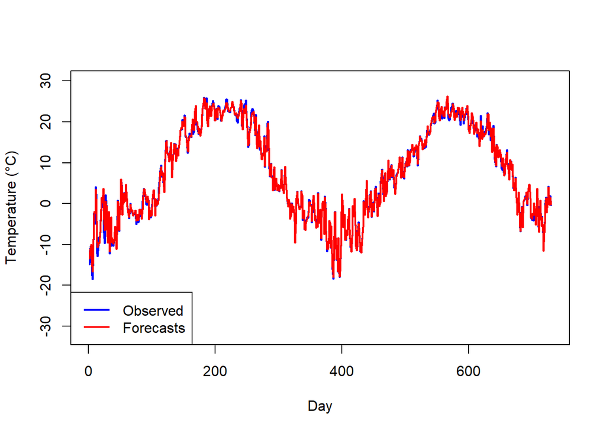

```r
t <- seq(1:nrow(Ontario.Daily))
plot(t, Ontario.Daily$Temperature, col="blue", xlab = "Day", ylab ="Temperature (°C)", type="l", lwd = 2, ylim = c(-32,30))
lines(t, fore.nnetar.Temp2$.mean, col="red", lwd = 2)
legend("bottomleft", legend = c("Observed", "Forecasts"), col = c("blue","red"), lty = 1, lwd = 2)
```

## New Plot

```r
nn.Temp.table <- tsibble(
  Date = Temp.Ontario.Daily$Date,
  Observed = Temp.Ontario.Daily$Temperature,
  Forecasts = fore.nnetar.Temp2$.mean
)
```

```
## Using `Date` as index variable.
```

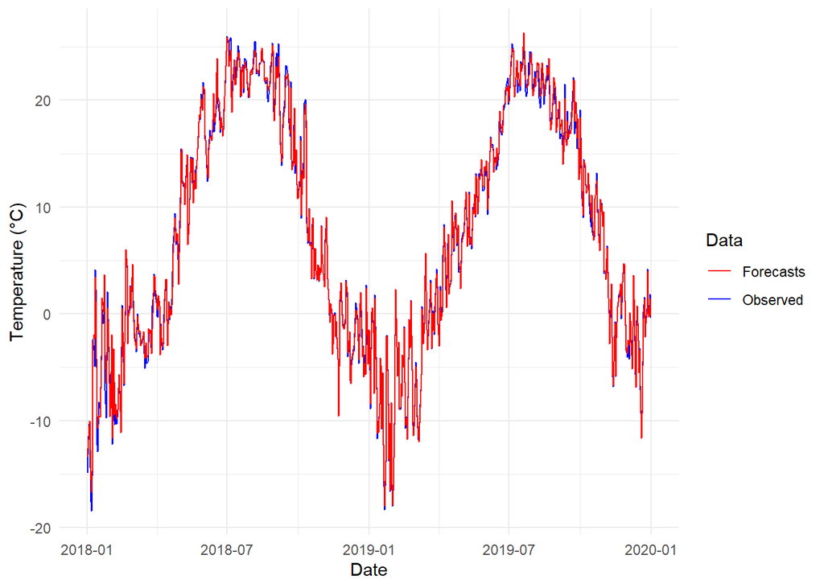

```r
library(ggplot2)

ggplot(data = nn.Temp.table, aes(x = Date)) +
  geom_line(aes(y = Observed, color = "Observed")) +
  geom_line(aes(y = Forecasts, color = "Forecasts")) +
  labs(y = "Temperature (°C)",
       x = "Date") +
  scale_color_manual(name = "Data",
                     values = c(Observed = "blue", Forecasts = "red"),
                     labels = c(Observed = "Observed", Forecasts = "Forecasts")) +
  theme_minimal()
```

### Fit different models to identify the best fit model for electricity demand

```r
## Train and testing datasets
## Training data: 80% of data 730*0.80 = 584
## Testing data: 730-584 = 146

trainOntario = Ontario.Daily[1:584,]
testOntario =  Ontario.Daily[585:730,]
head(trainOntario)
```

```
## # A tsibble: 6 x 15 [1D]
##   Date       Demand Temperature Holiday Precipitation IrradianceSurface
##   <date>      <dbl>       <dbl> <lgl>           <dbl>             <dbl>
## 1 2018-01-01 16931.       -14.9 TRUE           0.0216              52.0
## 2 2018-01-02 17953.       -11.4 FALSE          0.0244              41.9
## 3 2018-01-03 18123.       -10.3 FALSE          0.0231              48.7
## 4 2018-01-04 18050.       -11.2 FALSE          0.0263              56.7
## 5 2018-01-05 18961.       -17.6 FALSE          0.0532              42.2
## 6 2018-01-06 18514.       -18.5 FALSE          0.0181              47.7
## # ℹ 9 more variables: IrradianceToa <dbl>, Snowfall <dbl>, SnowMass <dbl>,
## #   CloudCover <dbl>, AirDensity <dbl>, Day_Type <chr>, Temperature2 <dbl>,
## #   HolidayNew <dbl>, Day_TypeNew <dbl>
```

```r
head(testOntario)
```

```
## # A tsibble: 6 x 15 [1D]
##   Date       Demand Temperature Holiday Precipitation IrradianceSurface
##   <date>      <dbl>       <dbl> <lgl>           <dbl>             <dbl>
## 1 2019-08-08 16558         21.8 FALSE         0.138                214.
## 2 2019-08-09 15524.        20.2 FALSE         0.0752               281.
## 3 2019-08-10 13968.        19.3 FALSE         0.0399               297.
## 4 2019-08-11 14527.        20.5 FALSE         0.00356              278.
## 5 2019-08-12 17211.        22.4 FALSE         0.0285               202.
## 6 2019-08-13 17536.        22.6 FALSE         0.0518               261.
## # ℹ 9 more variables: IrradianceToa <dbl>, Snowfall <dbl>, SnowMass <dbl>,
## #   CloudCover <dbl>, AirDensity <dbl>, Day_Type <chr>, Temperature2 <dbl>,
## #   HolidayNew <dbl>, Day_TypeNew <dbl>
```

```r
## TSLM
TSLM.Reg.Demand <- trainOntario %>%
  model(tslm = TSLM(Demand ~ Temperature + Temperature2 + HolidayNew + Day_TypeNew))

report(TSLM.Reg.Demand)
```

```
## Series: Demand
## Model: TSLM
##
## Residuals:
##      Min       1Q   Median       3Q      Max
## -2846.35  -623.91    31.84   656.61  1937.31
##
## Coefficients:
##                Estimate Std. Error t value Pr(>|t|)
## (Intercept)  14071.1791    72.3370 194.523   <2e-16 ***
## Temperature   -161.5643     5.1866 -31.151   <2e-16 ***
## Temperature2    10.4957     0.2932  35.794   <2e-16 ***
## HolidayNew     511.1362   228.7259   2.235   0.0258 *
## Day_TypeNew   1207.6245    77.4602  15.590   <2e-16 ***
## ---
## Signif. codes:  0 '***' 0.001 '**' 0.01 '*' 0.05 '.' 0.1 ' ' 1
##
## Residual standard error: 839.6 on 579 degrees of freedom
## Multiple R-squared: 0.726,   Adjusted R-squared: 0.7241
## F-statistic: 383.5 on 4 and 579 DF, p-value: < 2.22e-16
```

```r
TSLM.Reg.fore <- TSLM.Reg.Demand %>% forecast(testOntario)

TSLM.Reg.Demand.Accuracy <- fabletools::accuracy(TSLM.Reg.fore, testOntario)

xtable(TSLM.Reg.Demand.Accuracy)
```

```
## % latex table generated in R 4.4.0 by xtable 1.8-4 package
## % Fri Jan  3 19:57:37 2025
## \begin{table}[ht]
## \centering
## \begin{tabular}{rllrrrrrrrr}
##   \hline
##  & .model & .type & ME & RMSE & MAE & MPE & MAPE & MASE & RMSSE & ACF1 \\
##   \hline
## 1 & tslm & Test & -98.08 & 877.95 & 777.70 & -1.01 & 5.21 &  &  & 0.89 \\
##    \hline
## \end{tabular}
## \end{table}
```

```r
## ARIMA model
ARIMA.Reg.Demand <- trainOntario %>%
  model(arima =  ARIMA(Demand ~ Temperature + Temperature2 + HolidayNew + Day_TypeNew))

report(ARIMA.Reg.Demand)
```

```
## Series: Demand
## Model: LM w/ ARIMA(2,0,2)(2,0,0)[7] errors
##
## Coefficients:
##          ar1      ar2      ma1      ma2     sar1    sar2  Temperature
##       1.3658  -0.3723  -0.5802  -0.1989  -0.0187  0.0735     -38.8331
## s.e.  0.1024   0.1007   0.1012   0.0603   0.0447  0.0426       7.6149
##       Temperature2  HolidayNew  Day_TypeNew   intercept
##             8.3902    646.1343    1044.8220  13621.6541
## s.e.        0.3845    106.0158      47.8593    643.8879
##
## sigma^2 estimated as 236803:  log likelihood=-4437.84
## AIC=8899.68   AICc=8900.22   BIC=8952.11
```

```r
ARIMA.Reg.fore <- ARIMA.Reg.Demand %>% forecast(testOntario)

ARIMA.Reg.Demand.Accuracy <- fabletools::accuracy(ARIMA.Reg.fore, testOntario)

xtable(ARIMA.Reg.Demand.Accuracy)
```

```
## % latex table generated in R 4.4.0 by xtable 1.8-4 package
## % Fri Jan  3 19:57:42 2025
## \begin{table}[ht]
## \centering
## \begin{tabular}{rllrrrrrrrr}
##   \hline
##  & .model & .type & ME & RMSE & MAE & MPE & MAPE & MASE & RMSSE & ACF1 \\
##   \hline
## 1 & arima & Test & 160.65 & 1443.74 & 1246.76 & 0.49 & 8.17 &  &  & 0.96 \\
##    \hline
## \end{tabular}
## \end{table}
```

```r
## nnetar model
nnetar.Reg.Demand <- trainOntario %>%
  model(NNETAR(Demand ~ Temperature + Temperature2 + HolidayNew + Day_TypeNew))

nnetar.Reg.Demand
```

```
## # A mable: 1 x 1
##   `NNETAR(Demand ~ Temperature + Temperature2 + HolidayNew + Day_TypeNew)`
##                                                                    <model>
## 1                                                       <NNAR(23,1,14)[7]>
```

```r
nnetar.Reg.fore <- nnetar.Reg.Demand %>% forecast(testOntario)

nnetar.Reg.Demand.Accuracy <- fabletools::accuracy(nnetar.Reg.fore, testOntario)

xtable(nnetar.Reg.Demand.Accuracy)
```

```
## % latex table generated in R 4.4.0 by xtable 1.8-4 package
## % Fri Jan  3 20:26:48 2025
## \begin{table}[ht]
## \centering
## \begin{tabular}{rllrrrrrrrr}
##   \hline
##  & .model & .type & ME & RMSE & MAE & MPE & MAPE & MASE & RMSSE & ACF1 \\
##   \hline
## 1 & NNETAR(Demand \~{} Temperature + Temperature2 + HolidayNew + Day\_TypeNew) & Test & 8.09 & 734.44 & 561.19 & -0.08 & 3.70 &  &  & 0.80 \\
##    \hline
## \end{tabular}
## \end{table}
```

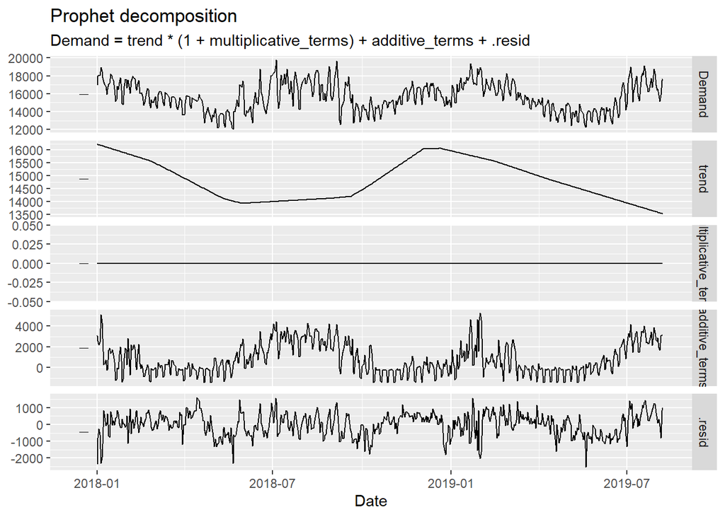

```r
### Prophet Model
Prophet.Reg.Demand <- trainOntario %>%
  model(prophet(Demand ~ Temperature + Temperature2 + HolidayNew + Day_TypeNew))

Prophet.Reg.Demand %>% components() %>% autoplot()
```

```r
Prophet.Reg.fore <- Prophet.Reg.Demand %>% forecast(testOntario)

Prophet.Reg.Demand.Accuracy <- fabletools::accuracy(Prophet.Reg.fore, testOntario)

xtable(Prophet.Reg.Demand.Accuracy)
```

```
## % latex table generated in R 4.4.0 by xtable 1.8-4 package
## % Fri Jan  3 20:26:55 2025
## \begin{table}[ht]
## \centering
## \begin{tabular}{rllrrrrrrrr}
##   \hline
##  & .model & .type & ME & RMSE & MAE & MPE & MAPE & MASE & RMSSE & ACF1 \\
##   \hline
## 1 & prophet(Demand \~{} Temperature + Temperature2 + HolidayNew + Day\_TypeNew) & Test & 1943.52 & 2603.57 & 1998.84 & 12.42 & 12.81 &  &  & 0.97 \\
##    \hline
## \end{tabular}
## \end{table}
```

```r
Demand.Model.Accuracy <- rbind(TSLM.Reg.Demand.Accuracy, ARIMA.Reg.Demand.Accuracy, nnetar.Reg.Demand.Accuracy, Prophet.Reg.Demand.Accuracy)
Demand.Model.Accuracy
```

```
## # A tibble: 4 × 10
##   .model               .type      ME  RMSE   MAE     MPE  MAPE  MASE RMSSE  ACF1
##   <chr>                <chr>   <dbl> <dbl> <dbl>   <dbl> <dbl> <dbl> <dbl> <dbl>
## 1 tslm                 Test   -98.1   878.  778. -1.01    5.21   NaN   NaN 0.887
## 2 arima                Test   161.   1444. 1247.  0.492   8.17   NaN   NaN 0.961
## 3 NNETAR(Demand ~ Tem… Test     8.09  734.  561. -0.0781  3.70   NaN   NaN 0.802
## 4 prophet(Demand ~ Te… Test  1944.   2604. 1999. 12.4    12.8    NaN   NaN 0.970
```

Note that among the 4 regression models consider for Demand, nnetar has the best forecast accuracy. Thus, nnetar will be used to obtain fuzzy forecasts of Demand using fuzzy forecasts of Temperature.

Forecast plot for the best fit model for Demand:

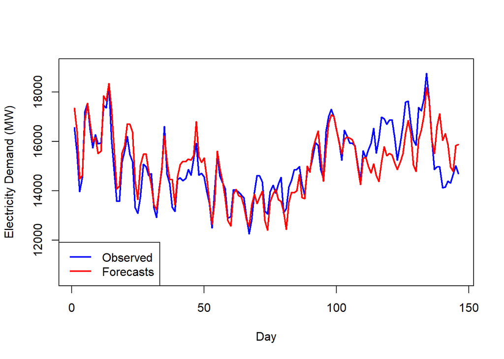

```r
t <- seq(1:nrow(testOntario))
plot(t, testOntario$Demand, col="blue", xlab = "Day", ylab ="Electricity Demand (MW)", type="l", lwd = 2, ylim = c(10500, 19000))
lines(t, nnetar.Reg.fore$.mean, col="red", lwd = 2)
legend("bottomleft", legend = c("Observed", "Forecasts"), col = c("blue","red"), lty = 1, lwd = 2)
```

## New Plot

```r
nn.Temp.table <- tsibble(
  Date = testOntario$Date,
  Observed = testOntario$Demand,
  Forecasts = nnetar.Reg.fore$.mean
)
```

```
## Using `Date` as index variable.
```

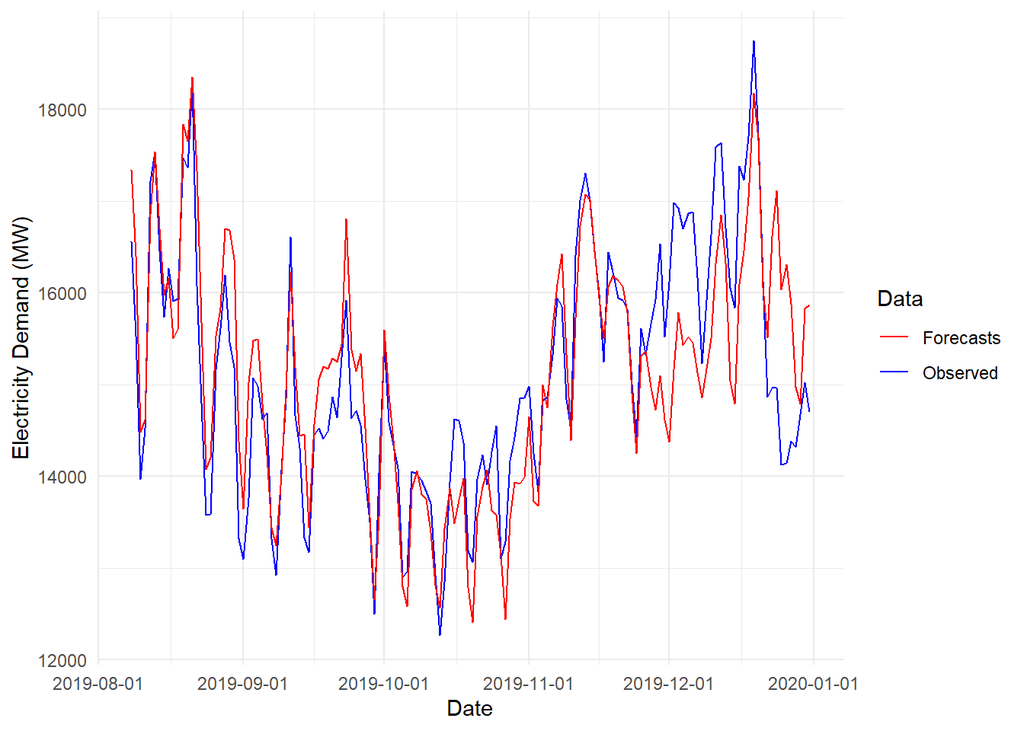

```r
ggplot(data = nn.Temp.table, aes(x = Date)) +
  geom_line(aes(y = Observed, color = "Observed")) +
  geom_line(aes(y = Forecasts, color = "Forecasts")) +
  labs(y = "Electricity Demand (MW)",
       x = "Date") +
  scale_color_manual(name = "Data",
                     values = c(Observed = "blue", Forecasts = "red"),
                     labels = c(Observed = "Observed", Forecasts = "Forecasts")) +
  scale_x_date(date_labels = "%Y-%m-%d", date_breaks = "1 month") +  # Specify date format and breaks
  theme_minimal()
```